# Module 2

APCV 302 2023 FA 7W1

Author

Affiliation

[Jared Parker](https://arizona.digication.com/eportfolio-for-j-parker)

[Student at University of Arizona](https://azcast.arizona.edu)

Published

September 10, 2023

## Chapter 2

### Question 1 ([relevant section](https://onlinestatbook.com/2/graphing_distributions/graphing_qualitative.html) & [relevant section](https://onlinestatbook.com/2/graphing_distributions/intro_quantitative.html))

> Name some ways to graph quantitative variables and some ways to graph qualitative variables.

Quantitative variables have far more methods in which to display their information. As Lane states in chapter 2 “Some graph types such as stem and leaf displays are best-suited for small to moderate amounts of data, whereas others such as histograms are best-suited for large amounts of data. Graph types such as box plots are good at depicting differences between distributions. Scatter plots are used to show the relationship between two variables.”

Pie charts are a great way to display a small number of qualitative variables and their relative frequencies; bar charts are preferred if there are larger numbers of categories as they are more effective at properly conveying the information.

### Question 5 ([relevant section](https://onlinestatbook.com/2/graphing_distributions/boxplots.html))

> In a box plot, what percent of the scores are between the lower and upper hinges?

The upper hinge represents the 75th percentile of the data, while the lower hinge is the 25th percentile so the area between the two consists of the middle 50 percent of the data.

### Question 7 ([relevant section](https://onlinestatbook.com/2/graphing_distributions/graphing_qualitative.html))

```r
#|label: Table and Graph Creation
#|column: margin
Eye_df <- data.frame(
  "Eye Color" = factor(c("Brown", "Blue", "Green", "Gray"), #assigning the eye color a categorical factor
                     levels = c("Brown", "Blue", "Green", "Gray")), #maintain position in table
  "Number of Students" = c(11, 10, 4, 1)) #assign values to corresponding colors
colors <- c("brown", "blue", "green", "gray")
```

> For the data from the 1977 Stat. and Biom. 200 class for eye color, construct:
> 1. pie graph
> 2. horizontal bar graph
> 3. vertical bar graph
> 4. a frequency table with the relative frequency of each eye color

| Eye.Color | Number.of.Students |
| --- | --- |
| Brown | 11 |
| Blue | 10 |
| Green | 4 |
| Gray | 1 |

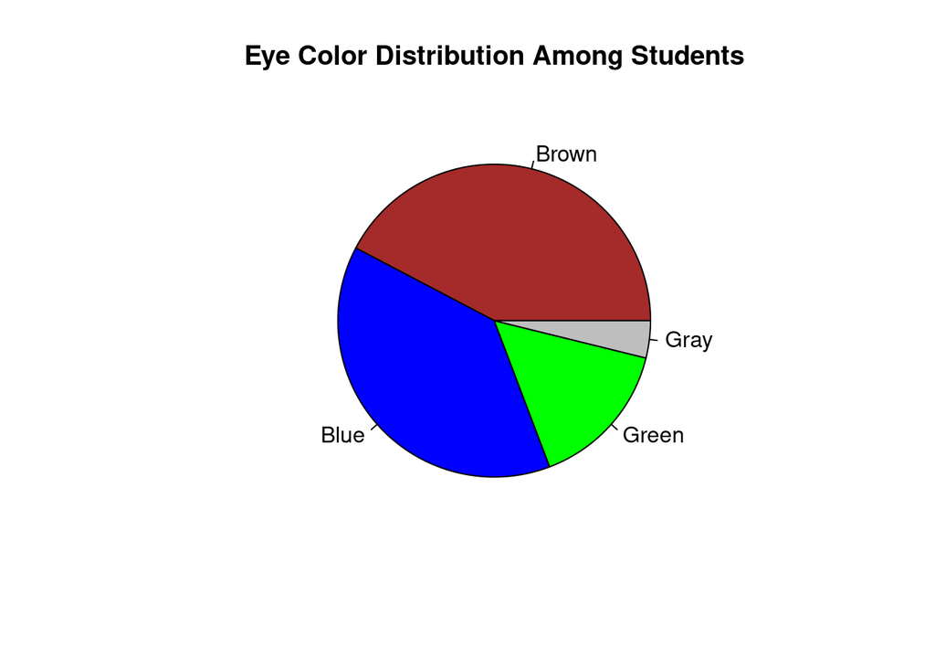

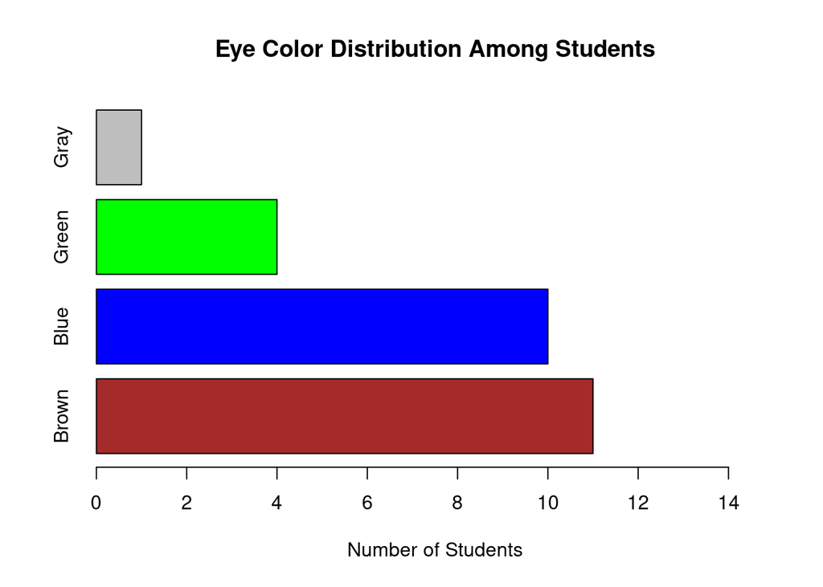

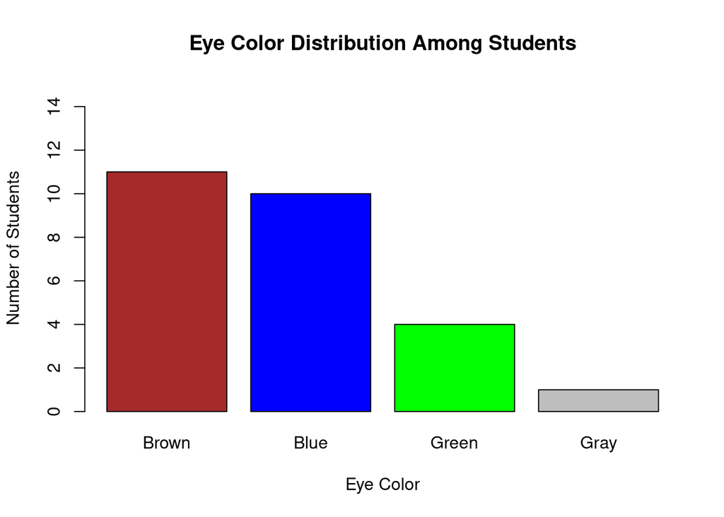

| Eye.Color | Number.of.Students | RelFreq |
| --- | --- | --- |
| Brown | 11 | 0.4230769 |
| Blue | 10 | 0.3846154 |
| Green | 4 | 0.1538462 |
| Gray | 1 | 0.0384615 |

```r
#Pie Chart
pie(Eye_df$Number.of.Students,
    labels = Eye_df$Eye.Color,
    col = colors,
    main = "Eye Color Distribution Among Students")
#Horizontal Bar Chart
barplot(Eye_df$Number.of.Students,
        names.arg = Eye_df$Eye.Color,
        col = colors,
        horiz = TRUE, #turn graph horizontal
        main = "Eye Color Distribution Among Students",
        xlab = "Number of Students",
        xlim = c(0, 15))  # Set the x-axis limits to 0 and 15
#Vertical Bar Chart
barplot(Eye_df$Number.of.Students,
        names.arg = Eye_df$Eye.Color,
        col = colors,
        main = "Eye Color Distribution Among Students",
        xlab = "Eye Color",
        ylab = "Number of Students",
        ylim = c(0, 15))  # Set the y-axis limits to 0 and 15
#Frequency Table
stu_total <- sum(Eye_df$Number.of.Students)
Eye_df$RelFreq <- Eye_df$Number.of.Students/stu_total
knitr::kable(Eye_df)
```

## Chapter 3

### Question 3 ([relevant section](https://onlinestatbook.com/2/summarizing_distributions/measures.html)) & ([relevant section](https://onlinestatbook.com/2/summarizing_distributions/variability.html))

> Make up three data sets with 5 numbers each that have:
> - a. the same mean but different standard deviations
> - b. the same mean but different medians
> - c. the same median but different means

```r
#Part A
n <- 5 #number of data values according to question
dsa1 <- c(67, 23, 60, 96, 92) #setting first values by 6 rolls of 100-sided dice
a_mean <- mean(dsa1)
dsa2 <- c(1, 2, 3, 4, ((n*a_mean)-10)) #adjusting standard deviation
dsa3 <- c(3, 5, 12, 33, ((n*a_mean)-sum(3,5,12,33)))
#Part B is also accomplished with the above code
#Part c
des_med <- 21 #desired median
dsca <- abs(rnorm(n, mean = 6, sd = 8))  #generate random data with positive values
ca_med_adj <- des_med - median(dsca)
dsc1 <- dsca + ca_med_adj

dscb <- abs(rnorm(n, mean = 101, sd = 33))  #generate random data with positive values
cb_med_adj <- des_med - median(dscb)
dsc2 <- dscb + cb_med_adj

dscc <- abs(rnorm(n, mean = 4949, sd = 123))  #generate random data with positive values
cc_med_adj <- des_med - median(dscc)
dsc3 <- dscc + cc_med_adj
```

### Part A & B.

Table 1

| x |
| --- |
| 67 |
| 23 |
| 60 |
| 96 |
| 92 |

```
[1] "MEAN= 67.6"
```

```
[1] "SD= 29.3649450876381"
```

```
[1] "MEDIAN= 67"
```

Table 2

| x |
| --- |
| 1 |
| 2 |
| 3 |
| 4 |
| 328 |

```
[1] "MEAN= 67.6"
```

```
[1] "SD= 145.572318797222"
```

```
[1] "MEDIAN= 3"
```

Table 3

| x |
| --- |
| 3 |
| 5 |
| 12 |
| 33 |
| 285 |

```
[1] "MEAN= 67.6"
```

```
[1] "SD= 122.109786667572"
```

```
[1] "MEDIAN= 12"
```

> These three tables have the same mean of 67.6 with varying standard deviation. This is achieved by modulating the variation of the numbers while creating a variable dependent upon a fixed mean. This also achieves the modulation of the median variable while maintaining a fixed mean.

### Part C.

Table 1

| x |
| --- |
| 23.96123 |
| 20.49261 |
| 35.26219 |
| 21.00000 |
| 19.05328 |

```
[1] "MEAN= 23.9538609774694"
```

```
[1] "MEDIAN= 21"
```

Table 2

| x |
| --- |
| 21.000000 |
| 81.346308 |
| 14.408105 |
| 23.022119 |
| -4.192524 |

```
[1] "MEAN= 27.1168017133287"
```

```
[1] "MEDIAN= 21"
```

Table 3

| x |
| --- |
| 205.350706 |
| 3.354686 |
| 33.686708 |
| 21.000000 |
| -15.556625 |

```
[1] "MEAN= 49.5670951326263"
```

```
[1] "MEDIAN= 21"
```

> As you can see, these three tables have varying means, but the exact same medians of 21.

### Question 16 ([relevant section](https://onlinestatbook.com/2/summarizing_distributions/shapes.html))

> If the mean time to respond to a stimulus is much higher than the median time to respond, what can you say about the shape of the distribution of response times?

The relationship between a data set with a mean that is a much higher value than the median of the data indicates a positively skewed distribution. This will mean the shape will have a tail extending towards the right with a large amount of values towards the left.

### Question 17 ([relevant section](https://onlinestatbook.com/2/summarizing_distributions/additional_measures.html))

> A set of numbers is transformed by taking the log base 10 of each number. The mean of the transformed data is 1.65. What is the geometric mean of the untransformed data?

The geometric mean of a data set can be found via

1. Taking the $Log_{10}$ of each data value
2. Calculating the arithmetic mean of the new values
3. Raise 10 to an exponential power equal to the arithmetic mean

$\Huge 10^{\frac{1}{n} \sum_{i=1}^{n} \log_{10}(X_i)}$

The geometric mean of a data set with a transformed arithmetic mean of 1.65 will be 44.6683592